# CuSUM

The task was simple in this notebook:

1. *Using July through October daily-high-temperature data for Atlanta for 1996 through 2015, use a CUSUM approach to identify when unofficial summer ends (i.e., when the weather starts cooling off) each year. You can get the data that you need from the file temps.txt or online, for example at http://www.iweathernet.com/atlanta-weather-records or https://www.wunderground.com/history/airport/KFTY/2015/7/1/CustomHistory.html
2. *Use a CUSUM approach to make a judgment of whether Atlanta’s summer climate has gotten warmer in that time (and if so, when).*

I used MS Excel and have provided a link to the dashboard I created here: https://gtvault-my.sharepoint.com/:x:/g/personal/tjefferies3_gatech_edu/EVDfKREiezZEoqehE-8wgFkBSsVx8oNhN-GnYYj22d4vaA?e=AAgJ7Y

## Question 6.2

1. *Using July through October daily-high-temperature data for Atlanta for 1996 through 2015, use a CUSUM approach to identify when unofficial summer ends (i.e., when the weather starts cooling off) each year. You can get the data that you need from the file temps.txt or online, for example at http://www.iweathernet.com/atlanta-weather-records or https://www.wunderground.com/history/airport/KFTY/2015/7/1/CustomHistory.html . You can use R if you’d like, but it’s straightforward enough that an Excel spreadsheet can easily do the job too.*
2. *Use a CUSUM approach to make a judgment of whether Atlanta’s summer climate has gotten warmer in that time (and if so, when).*

### 6.2.1

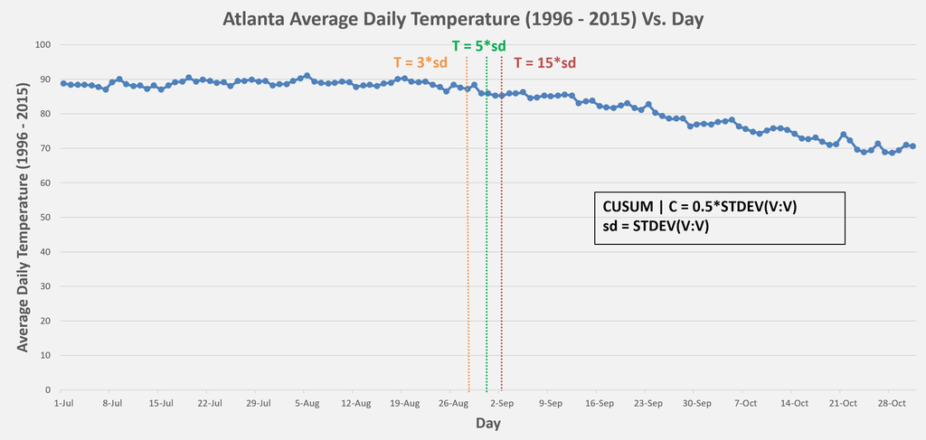

```r
display_jpeg(file="C:/Users/jeffe/Documents/GitHub/GA _TECH/ISYE 6501/Content/Week3/Q6.2.1 Graph.JPG")
```

I created the graph above in MS Excel and copy/pasted into this notebook. I quickly noticed that the values of critical value C and threshold T were crucial to determining the unofficial end of summer. I tried a spread of T values from 3***sd where sd is the Standard Deviation of the average high temperature provided for everyday between July-October for every year between 1996 and 2015. I held C constant to isolate T's effect on model outcome.

Lower values of T dragged the unofficial end of summer to the left, as the model is more sensitive to changes in the expected value. Higher values of T extended the summer. From prior knowledge, I expected the offical end of summer to be right around September 1st. I achieved an unofficial summer end of August 30 using a threshold T value of 5***sd, or the line plotted in green.

The graph below explores the effects that different values of C have on the model's prediction for the unoffical end of summer. For these set of tests, the T value was held constant at T = 5***sd. As C increases, the CUSUM statistic St is less sensitive to changes in the expected value. As C decreases, the CUSUM model is more sensitive to deviations from the expected value.

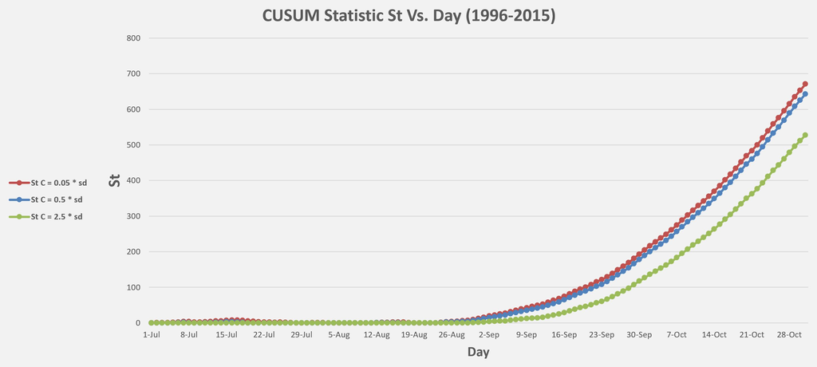

```r
display_jpeg(file="C:/Users/jeffe/Documents/GitHub/GA _TECH/ISYE 6501/Content/Week3/Q6.2.1 G2.JPG")
```

### 6.2.2

The second part of Q6.2 asks for an answer to the question:

*Has Atlanta's summer climate gotten warmer over the last 20 years?*

There are two ways to go about answering this question:

- *Is the summer getting longer?*
- *Is the summer getting hotter?*

Both methods require the use of the CUSUM method and a recording of the expected value for every summer we have data for. Both methods are very sensitive to the value chosen for the critical value C. In the chart below I have provided visual evidence for the claim that summers *are* getting longer in Atlanta. Picking a different value of C easily changes the narrative to reject the idea that the summer is getting longer. The bigger looming question (with regards to climate change anyway) should be what *threshold* is our planet capable of sustaining? What threshold are we ok with as a species?

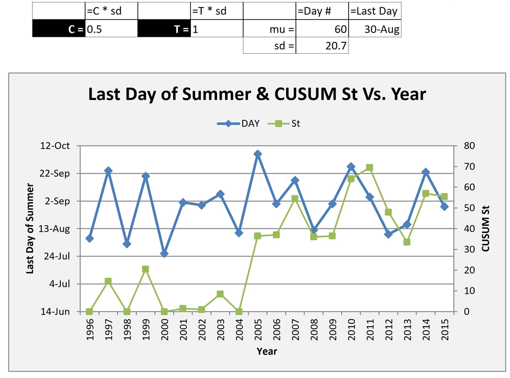

```r
display_jpeg(file="C:/Users/jeffe/Documents/GitHub/GA _TECH/ISYE 6501/Content/Week3/Q6.2.2 G1.JPG")
```

In the graph below, I provide visual evidence that the summer climate in Atlanta has gotten hotter. Again, the visuals presented are highly dependent on the critical value C chosen for the given CUSUM model.

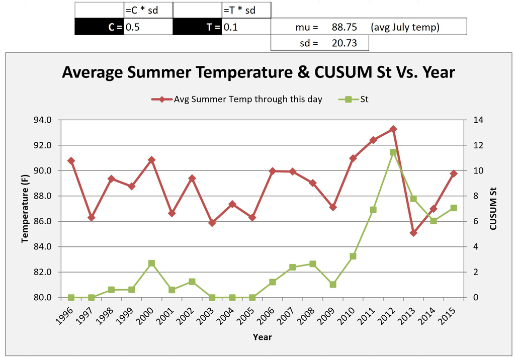

```r
display_jpeg(file="C:/Users/jeffe/Documents/GitHub/GA _TECH/ISYE 6501/Content/Week3/Q6.2.2 G2.JPG")
```